# Week 3: Understanding the probability of real world problems

University of Sydney

## Before we begin

- Week 4
- Assessments (in class tests, group work, research plan/paper)
- Labs

The world is not (always) linear

Probability

## Probability

- Probability theory is of practical value and intuitive meaning in connection with real or conceptual experiments (Feller 1950). The formal quantification of uncertainty.
- Uncertainty comes into the picture when we start doing statistical inference: what can we infer about a population parameter given sample statistics?
- Relative Frequency or Frequentist Approach: the probability of a particular outcome is the proportion of times that outcome would occur in a long run of repeated observations.

## Bernoulli distribution

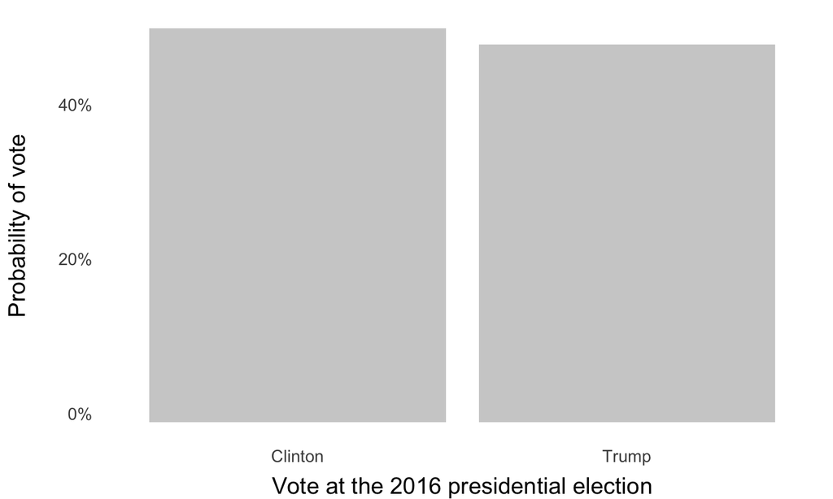

## Probability

- Coin toss. Dice rolls. Playing roulette. Selecting a random sample of people and observing people with different attributes. Election outcomes.
- Coin flips are independent. The outcome of *Flip 1* has no effect on the outcome of *Flip 2*.
- The binomial distribution (the sum of independent and identically distributed Bernoulli random variables) does not dictate the outcome of any given coin flip.
- Law of large numbers.
- Two types of variation: variance of the sample data, Y; variance of a sample statistic (eg the mean of Y) across repeated sampling (captured by the sampling distribution).

## Probability

We can replicate a coin toss in \(R\) with the code:

```r
rbinom(1, 1, .5)
```

## Sampling variation

- Flip a coin 4 times, compute a summary statistic (eg proportion of heads in 4 flips), repeat.
- The standard deviation of a sampling distribution goes by a special name: the standard error.
- It is an estimate of the dispersion of the sampling distribution.
- Sampling error/variability decreases as sample size increases.

## The binomial distribution

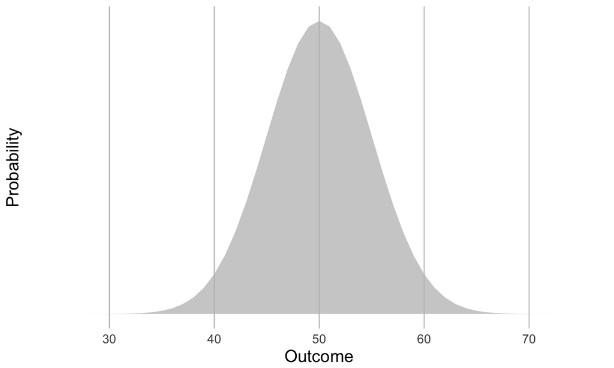

## The binomial distribution

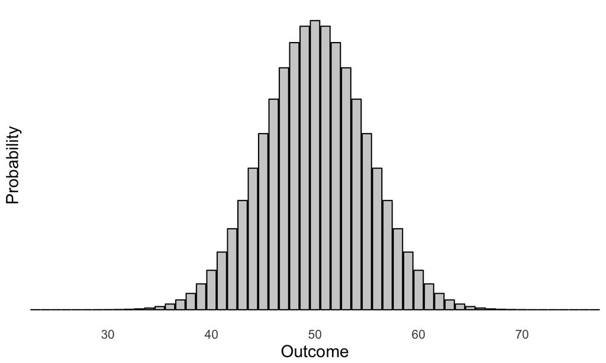

The world is still not simple

## (Un)fortunately, the world is not a series of coin flips

- With coin flips, we know the underlying distribution. For most interesting problems, we do not.
- Not every outcome has a binary set of outcomes (what if there are five outcomes?).
- We have some help, though. The law of large numbers, the central limits theorem.

Using logistic regression to estimate outcomes

## Linear regression

\(y = \alpha + \beta x + \epsilon\)

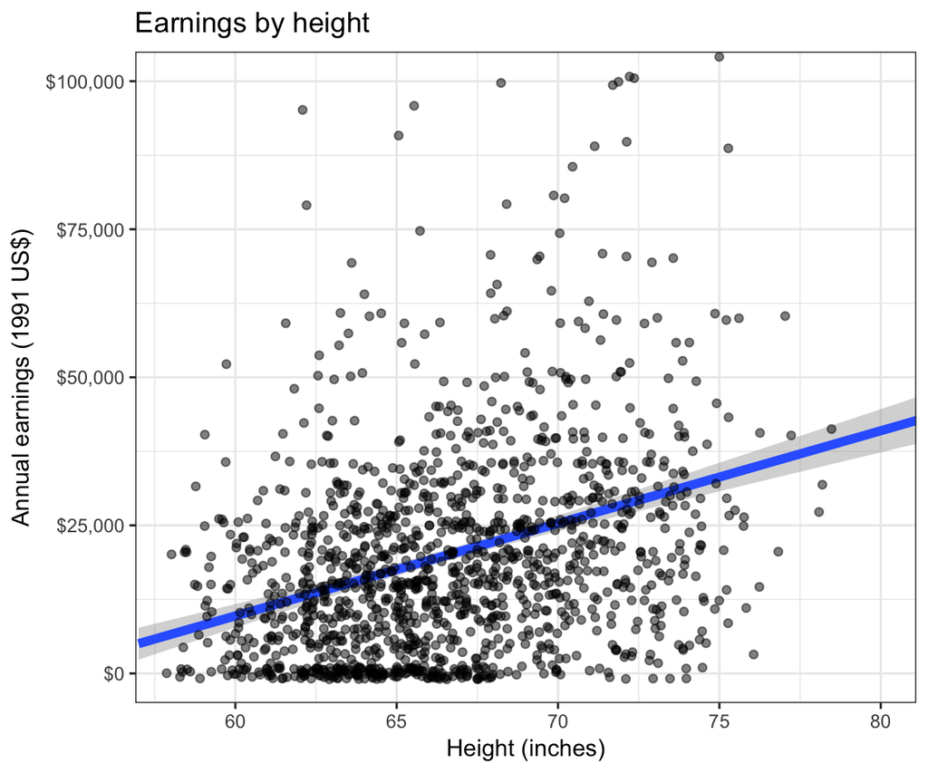

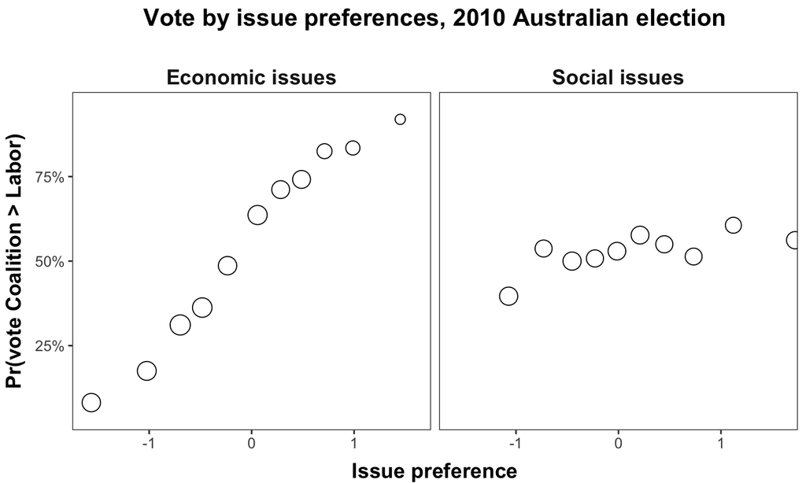

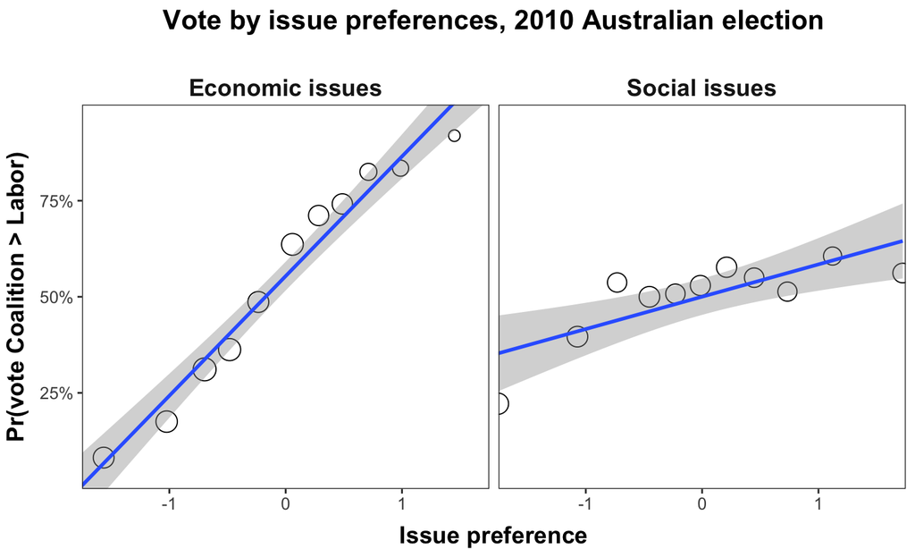

## Logistic regression

\(Pr(y = 1) = logit^{−1}(x_i\beta)\)

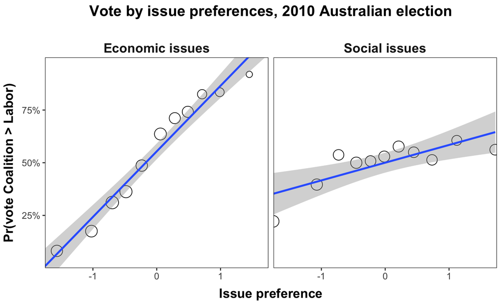

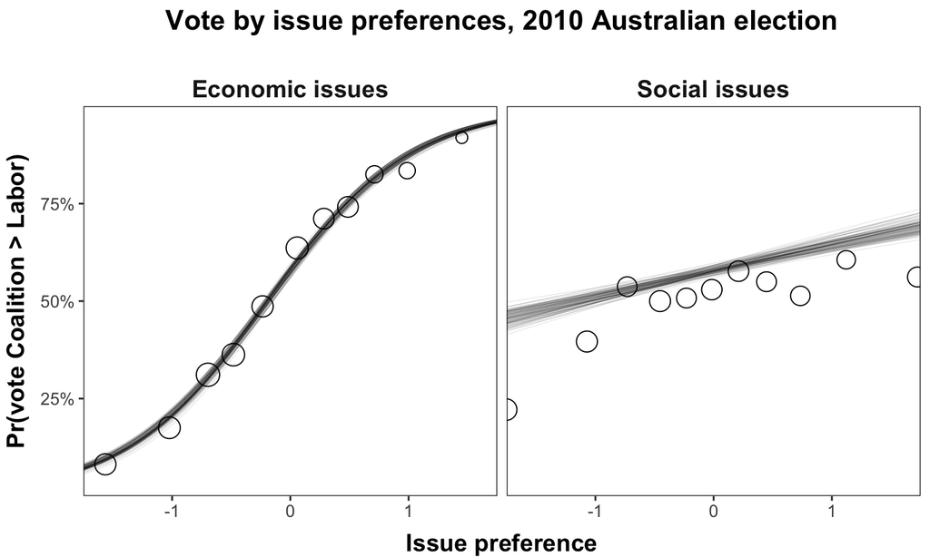

The importance of theory, subject matter expertise

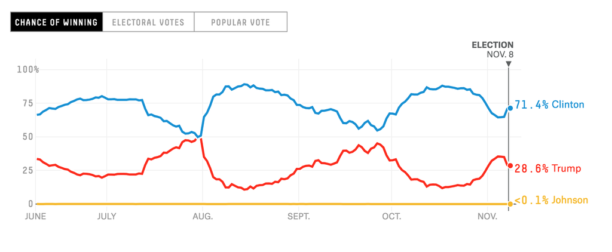

Source: [fivethirtyeight.com](https://projects.fivethirtyeight.com/2016-election-forecast/)

Problems with this?

## The electoral college

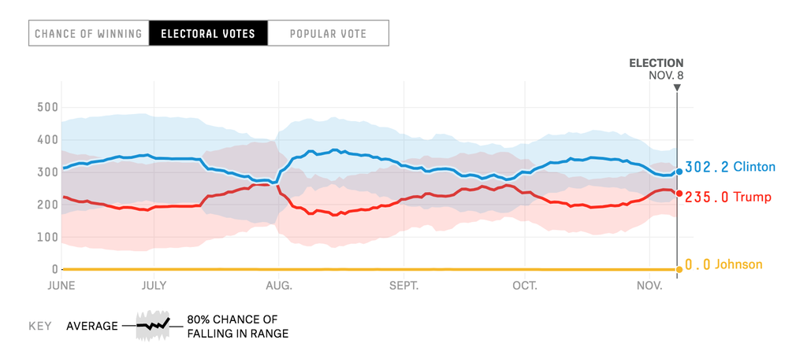

Source: [fivethirtyeight.com](https://projects.fivethirtyeight.com/2016-election-forecast/)

## Vote choice is a probability distribution

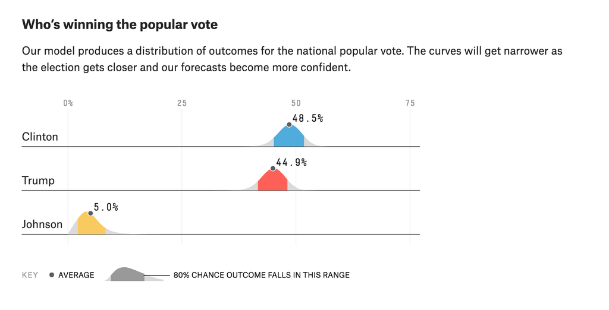

Source: [fivethirtyeight.com](https://projects.fivethirtyeight.com/2016-election-forecast/)

## So is the estimated electoral college vote

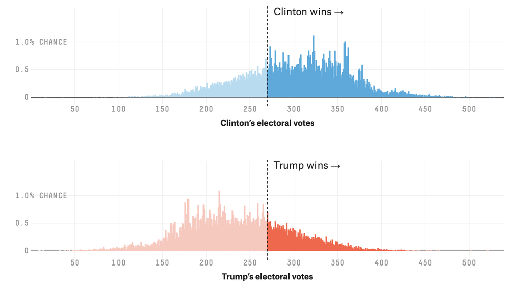

Source: [fivethirtyeight.com](https://projects.fivethirtyeight.com/2016-election-forecast/)

Next week: Predicting outcomes in the social world

## Office hours

*Dr Shaun Ratcliff*  
Email: shaun.ratcliff@sydney.edu.au  
Office: Room N416, Institute Building (H03)  
Office hours, by appointment:  
Tuesdays 3:30-4:30pm, Fridays 3-4pm

*Jaron Lee*  
Email: jaron.lee@sydney.edu.au  
Office: Level 4, Institute Building (H03)  
Office hour, by appointment: Fridays 4-5pm

*Nick James*  
Email: nicholas.james@sydney.edu.au  
Office: Level 5, The School of Information Technologies, Building J12  
Office hour: Friday 4-6pm